# Logistic Regression Models with R

Amandine Gamble

2026-03-26

# 1 Loading Data

We will use the *Palmer Penguin* data set available directly from the `palmerpenguins` package. You can learn more about the data at [allisonhorst.github.io/palmerpenguins](https://allisonhorst.github.io/palmerpenguins/).

Today, we will explore whether **biometrics can be used to predict sex**.

```r
# install.packages("palmerpenguins")
library(palmerpenguins)
library(ggplot2)
library(car)

dat <- as.data.frame(penguins) # rename dataset
str(dat) # structure of dataset
```

[output not shown]

Let’s focus on one species.

```r
dat_gen = subset(dat, species == "Gentoo" & !is.na(sex))
```

# 2 Exploring the data

*Which one of the variables included in the data may contribute be associated with sex?*

## 2.1 Plot

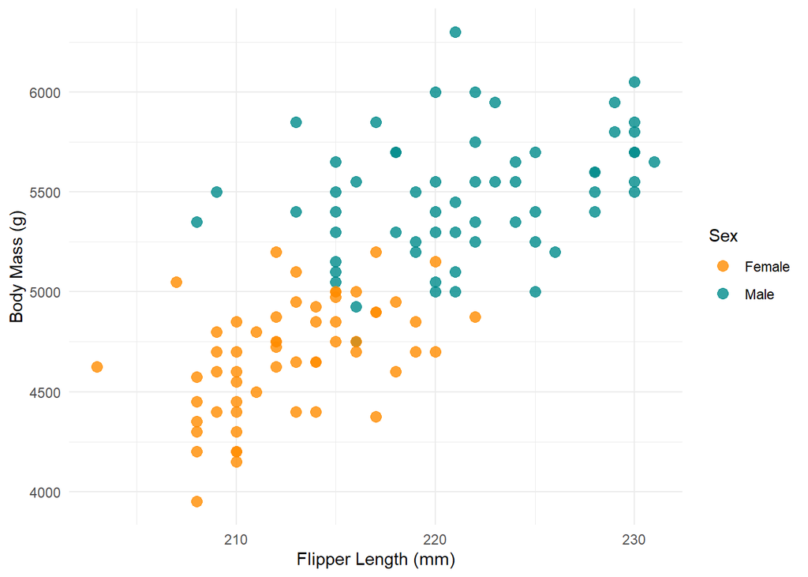

```r
ggplot(dat_gen, aes(x = flipper_length_mm, y = body_mass_g, color = sex)) +
  geom_point(size = 3, alpha = 0.8) +
  scale_color_manual(values = c("darkorange", "cyan4"),
                     name = "Sex",
                     labels = c("Female", "Male", "Unknown")) +
  scale_shape_manual(values = c(16, 17, 15),
                     name = "Species") +
  labs(
    x = "Flipper Length (mm)",
    y = "Body Mass (g)"
  ) +
  theme_minimal()
```

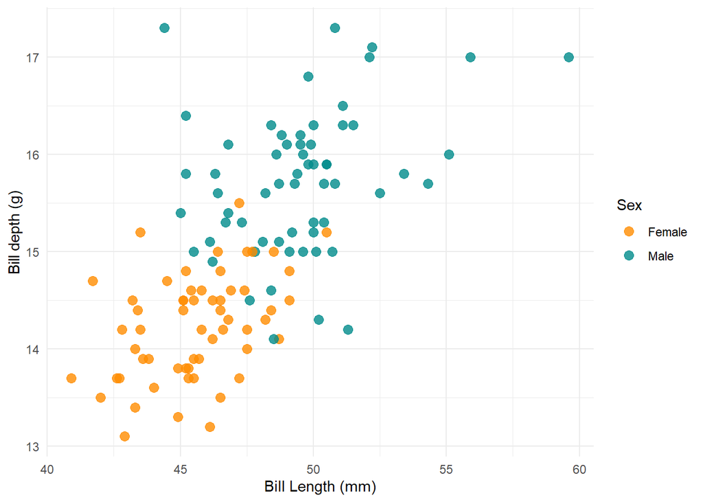

```r
ggplot(dat_gen, aes(x = bill_length_mm, y = bill_depth_mm, color = sex)) +
  geom_point(size = 3, alpha = 0.8) +
  scale_color_manual(values = c("darkorange", "cyan4"),
                     name = "Sex",
                     labels = c("Female", "Male", "Unknown")) +
  scale_shape_manual(values = c(16, 17, 15),
                     name = "Species") +
  labs(
    x = "Bill Length (mm)",
    y = "Bill depth (g)"
  ) +
  theme_minimal()
```

# 3 Logistic Regression to Identify Predictors of Sex

## 3.1 Re-plot

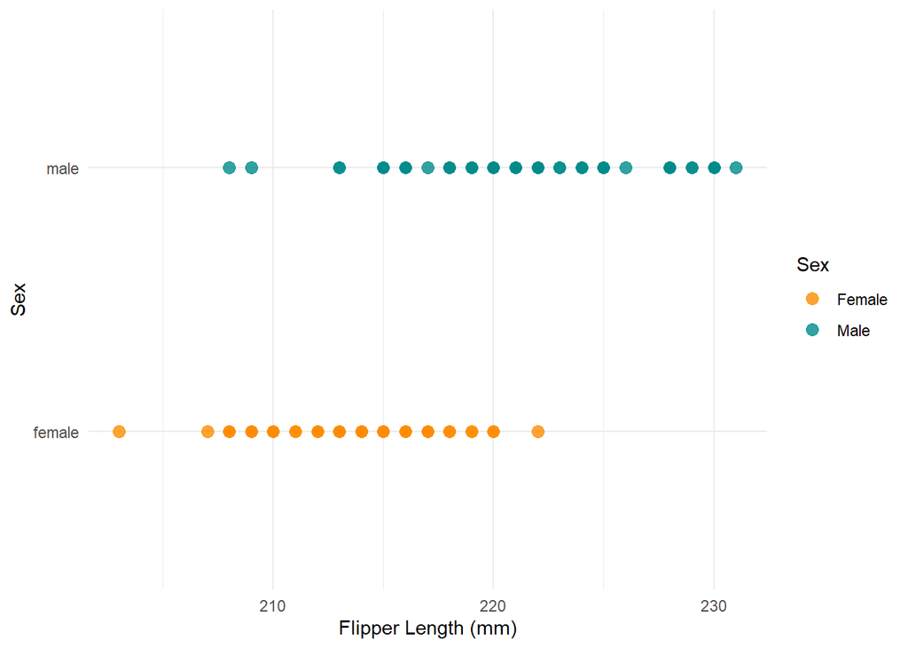

```r
ggplot(dat_gen, aes(x = flipper_length_mm, y = sex, color = sex)) +
  geom_point(size = 3, alpha = 0.8) +
  scale_color_manual(values = c("darkorange", "cyan4"),
                     name = "Sex",
                     labels = c("Female", "Male", "Unknown")) +
  scale_shape_manual(values = c(16, 17, 15),
                     name = "Species") +
  labs(
    x = "Flipper Length (mm)",
    y = "Sex"
  ) +
  theme_minimal()
```

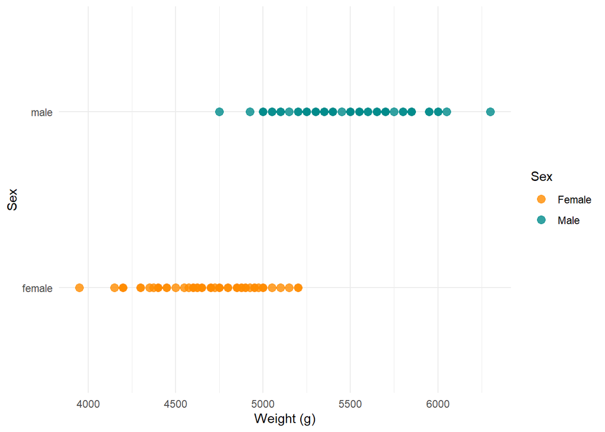

```r
ggplot(dat_gen, aes(x = body_mass_g, y = sex, color = sex)) +
  geom_point(size = 3, alpha = 0.8) +
  scale_color_manual(values = c("darkorange", "cyan4"),
                     name = "Sex",
                     labels = c("Female", "Male", "Unknown")) +
  scale_shape_manual(values = c(16, 17, 15),
                     name = "Species") +
  labs(
    x = "Weight (g)",
    y = "Sex"
  ) +
  theme_minimal()
```

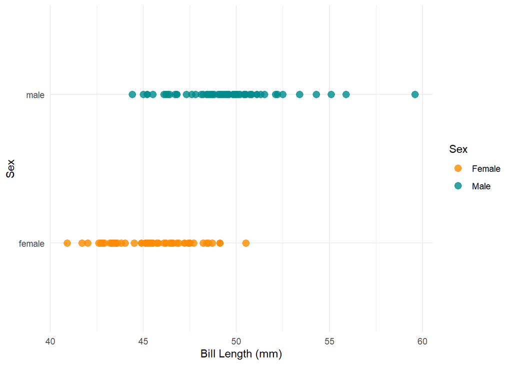

```r
ggplot(dat_gen, aes(x = bill_length_mm, y = sex, color = sex)) +
  geom_point(size = 3, alpha = 0.8) +
  scale_color_manual(values = c("darkorange", "cyan4"),
                     name = "Sex",
                     labels = c("Female", "Male", "Unknown")) +
  scale_shape_manual(values = c(16, 17, 15),
                     name = "Species") +
  labs(
    x = "Bill Length (mm)",
    y = "Sex"
  ) +
  theme_minimal()
```

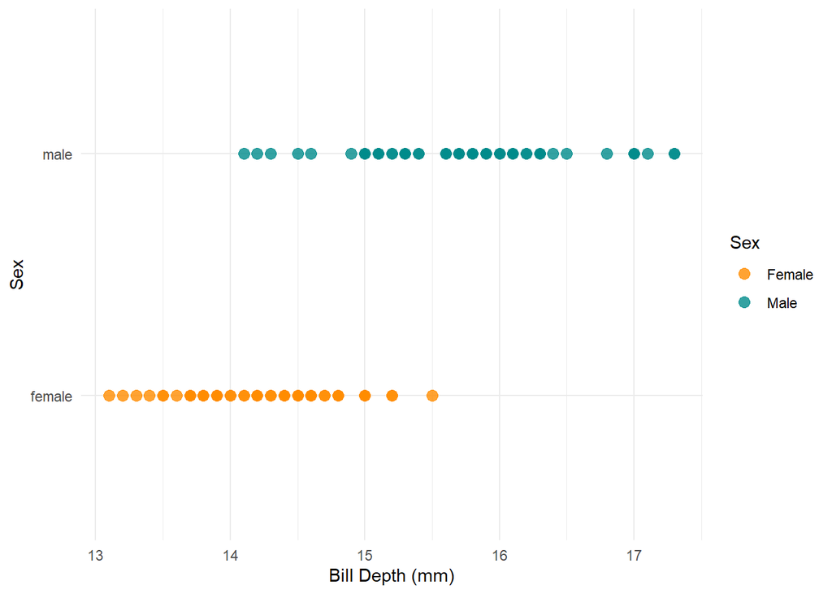

```r
ggplot(dat_gen, aes(x = bill_depth_mm, y = sex, color = sex)) +
  geom_point(size = 3, alpha = 0.8) +
  scale_color_manual(values = c("darkorange", "cyan4"),
                     name = "Sex",
                     labels = c("Female", "Male", "Unknown")) +
  scale_shape_manual(values = c(16, 17, 15),
                     name = "Species") +
  labs(
    x = "Bill Depth (mm)",
    y = "Sex"
  ) +
  theme_minimal()
```

*Does a linear relationship seem reasonable?*

# 4 Statistical Test

## 4.1 Assumptions

### 4.1.1 Independance

*Observations from each population are independent of one another*. This is likely the case (would be determined by the study design).

### 4.1.2 Linearity

*Linearity between the response variable odds and the explanatory variables*. Visible from the scatter plots above.

### 4.1.3 Absence of Collinearity

*Absence of collinearity between the explanatory variables*. Suspicious from the scatter plots above.

## 4.2 Model

#### 4.2.0.1 Model Fitting

```r
# Fit model
mod = glm(sex ~ flipper_length_mm + bill_length_mm + bill_depth_mm + body_mass_g,
          data = dat_gen,
          family = "binomial")
```

#### 4.2.0.2 Additional Assumption Checks

Double checking for the absence of collinearity.

```r
# Variance Inflation Factor
vif(mod)
```

[output not shown]

#### 4.2.0.3 Model Selection

```r
mod = glm(sex ~ flipper_length_mm,
          data = dat_gen,
          family = "binomial")
summary(mod)

mod = glm(sex ~ flipper_length_mm + bill_length_mm,
          data = dat_gen,
          family = "binomial")
summary(mod)

mod = glm(sex ~ flipper_length_mm + bill_length_mm + bill_depth_mm,
          data = dat_gen,
          family = "binomial")
summary(mod)

mod = glm(sex ~ flipper_length_mm + bill_length_mm + bill_depth_mm + body_mass_g,
          data = dat_gen,
          family = "binomial")
summary(mod)
```

[output not shown]

#### 4.2.0.4 Final Model

```r
mod = glm(sex ~ flipper_length_mm + bill_length_mm + bill_depth_mm,
          data = dat_gen,
          family = "binomial")
summary(mod)
```

[output not shown]

#### 4.2.0.5 Coefficient of Determination

```r
# Calculate R-squared
deviance <- summary(mod)$deviance
null_deviance <- summary(mod)$null.deviance
rsquared <- 1 - (deviance / null_deviance)
rsquared
```

[output not shown]

Based on a logistic regression with forward selection, we found that, if $p$ is the probability of being a male, we can write:

$\text{logit}(p) = \log(\frac{p}{1-p}) = \beta_0 + \beta_1 * flipper + \beta_2 * bill.length + \beta_3 * bill.depth$